# MODIStsp: A Tool for Automatic Preprocessing of MODIS Time Series - v2.0.0

## 4.3 **Specifying the processing parameters using a previously saved options file and overwriting some parameters**

Finally, it is possible to both specify a previously saved options file AND setting some parameters in the call to the function. This allows to **easily perform similar processings, by only updating the required arguments**, as in the examples below.

## 4.4 **Looping over different spatial extents**

Specifying the `spafile` parameter while setting the `spatmeth` parameter to “file” overrides for example the output extent of the selected Options File. This allows to perform the same preprocessing on different extents using a single Options File. For example:

```r
# Run the tool using the settings previously saved in a specific option file
# and specifying the extent from a spatial file allows to re-use the same
# processing settings to perform download and reprocessing on a different area
library(MODIStsp)
opts_file    <- system.file("testdata/test_MOD13A2.json", package = "MODIStsp")
spatial_file <- system.file("testdata/lakeshapes/garda_lake.shp", package = "MODIStsp")
MODIStsp(gui       = FALSE,
         opts_file = opts_file,
         spatmeth  = "file",
         spafile   = spatial_file,
         verbose   = FALSE)
```

```
## [1] "DONE"
```

```r
# --> Create a character array containing a list of shapefiles (or other spatial files)
extent_list <- list.files(system.file("testdata/lakeshapes/", package = "MODIStsp"), full.names = TRUE, "\\.shp$")

extent_list
```

```
## [1] "/tmp/Rtmpv1Rtca/Rinst64ff3aa06509/MODIStsp/testdata/lakeshapes//garda_lake.shp"
## [2] "/tmp/Rtmpv1Rtca/Rinst64ff3aa06509/MODIStsp/testdata/lakeshapes//iseo_lake.shp"
```

```r
# --> Loop on the list of spatial files and run MODIStsp using each of them to
# automatically define the output extent (A separate output folder is created for
# each input spatial file).

for (single_shape in extent_list) {
  MODIStsp(gui       = FALSE,
           opts_file = opts_file,
           spatmeth  = "file",
           spafile   = single_shape,
           verbose   = FALSE)
}

# output files are placed in separate folders:

outfiles_garda <- list.files(
  file.path(tempdir(), "MODIStsp/garda_lake/VI_16Days_1Km_v6/EVI"),
  full.names = TRUE)
outfiles_garda
```

```
## [1] "/tmp/RtmphlgYxY/MODIStsp/garda_lake/VI_16Days_1Km_v6/EVI/MOD13A2_EVI_2016_161.tif"
## [2] "/tmp/RtmphlgYxY/MODIStsp/garda_lake/VI_16Days_1Km_v6/EVI/MOD13A2_EVI_2016_177.tif"
```

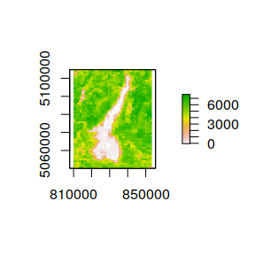

```r
library(raster)
plot(raster(outfiles_garda[1]))
```

```r
outfiles_iseo <- list.files(
  file.path(tempdir(), "MODIStsp/iseo_lake/VI_16Days_1Km_v6/EVI"),
  full.names = TRUE)
outfiles_iseo
```

```
## [1] "/tmp/RtmphlgYxY/MODIStsp/iseo_lake/VI_16Days_1Km_v6/EVI/MOD13A2_EVI_2016_161.tif"
## [2] "/tmp/RtmphlgYxY/MODIStsp/iseo_lake/VI_16Days_1Km_v6/EVI/MOD13A2_EVI_2016_177.tif"
```

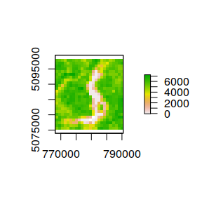

```r
plot(raster(outfiles_iseo[1]))
```

# 5 Scheduled Processing

Stand-alone non-interactive execution can be used to periodically and automatically update the time series of a selected product over a given study area. To do that, you should simply:

#### 5.0.0.1 On Linux

- edit your crontab by opening a terminal and type:

```bash
  crontab -e
```

- add an entry for the launcher. For example, if you have installed it in /usr/bin and you want to run the tool every day at 23.00, add the following row:

```bash
  0 23 * * * /bin/bash /usr/bin/MODIStsp -g -s "/yourpath/youroptions.json"
```

#### 5.0.0.2 On Windows